# Week 1 Homework

Charles-William Ruel

03NOV26

# Homework 2

Explore the notion of chance and how it applies to significance measures, and understand the role of the assumptions made by specific tests (e.g. the t-test)

## Question 1

```r
rmsdCalc <- function(DTcol, mean){
  meanDev <- 0
  for (i in 1:length(DTcol)){
    Dev <- mean - DTcol[i]
    sDev <- Dev^2
    meanDev <- meanDev + sDev
  }
  rmsd <- meanDev
  return(rmsd)
}

normSD <- function(DTcol, mean, type){
  DTcol <- DTcol[!is.na(DTcol)]
  n <- length(DTcol)
  rmsd <- rmsdCalc(DTcol, mean)
  if (type == 0){
    sdVal <- rmsd/(n-1)
  } else if (type == 1){
    sdVal <- rmsd/(n-2)
  } else if (type == -1){
    sdVal <- rmsd/n
  }
  sdVal <- sqrt(sdVal)
  return(sdVal)
}
```

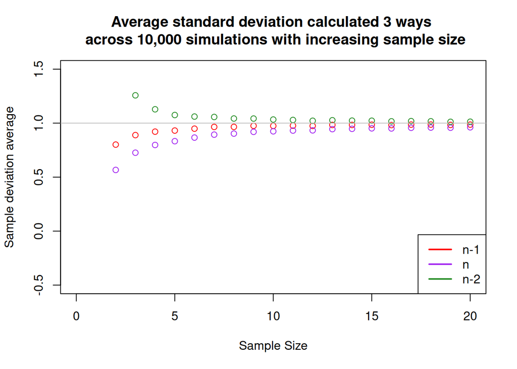

```r
set.seed(1234)
max.sample.size <- 20
sampleSize <- c(2:max.sample.size)
n.sim <- 10000
sd.ori <- matrix(0, nrow = n.sim, ncol = max.sample.size)
sd.n <- matrix(0, nrow = n.sim, ncol = max.sample.size)
sd.nMinus2 <- matrix(0, nrow = n.sim, ncol = max.sample.size)
j <- 1
for (i in sampleSize){
  for (i.sim in 1:n.sim){
    data <- rnorm(i)
    X <- mean(data)
    # Calc normal SD
    x.sd <- normSD(data, X, 0)
    sd.ori[i.sim, i] <- x.sd

    # repeat for rmsd/n
    x.sd <- normSD(data, X, -1)
    sd.n[i.sim, i] <- x.sd

    # repeat for rmsd/n-2
    x.sd <- normSD(data, X, 1)
    sd.nMinus2[i.sim, i] <- x.sd
  }
}

# Now lets calculate mean and spread of all values for each sample size
ori.mean <- as.numeric()
ori.sd <- as.numeric()

n.mean <- as.numeric()
n.sd <- as.numeric()

nMinus2.mean <- as.numeric()
nMinus2.sd <- as.numeric()

j <- 1
for (i in sampleSize){
  ori.mean[j] <- mean(sd.ori[,i])
  ori.sd[j] <- sd(sd.ori[,i])

  n.mean[j] <- mean(sd.n[,i])
  n.sd[j] <- sd(sd.n[,i])

  nMinus2.mean[j] <- mean(sd.nMinus2[,i])
  nMinus2.sd[j] <- sd(sd.nMinus2[,i])

  j <- j+1
}

sd.conv <- nMinus2.sd[max.sample.size-1]

# Finally lets make a plot for the mean of variance calculations and standard deviation.
plot(1, type = "n", xlab = "Sample Size", ylab="Sample deviation average", xlim=c(0,max.sample.size), ylim=c(-.5,1.5), main="Average standard deviation calculated 3 ways \n across 10,000 simulations with increasing sample size")

points(sampleSize, ori.mean, col = "red")
points(sampleSize, n.mean, col="purple")
points(sampleSize, nMinus2.mean, col = "forestgreen")

abline(h=1, col = "grey")

legend("bottomright", legend=c("n-1", "n", "n-2"), col=c("red", "purple", "forestgreen"), lwd=2)
```

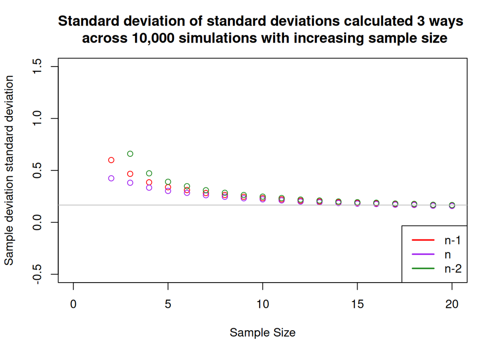

```r
plot(1, type = "n", xlab = "Sample Size", ylab="Sample deviation standard deviation", xlim=c(0,max.sample.size), ylim=c(-.5,1.5), main="Standard deviation of standard deviations calculated 3 ways \n across 10,000 simulations with increasing sample size")

points(sampleSize, ori.sd, col = "red")
points(sampleSize, n.sd, col="purple")
points(sampleSize, nMinus2.sd, col = "forestgreen")

abline(h=sd.conv, col = "grey")

legend("bottomright", legend=c("n-1", "n", "n-2"), col=c("red", "purple", "forestgreen"), lwd=2)
```

The calculated standard deviations averages across 10,000 simulations approach the known standard deviation as the sampling size increases, as we can see in the top figure above. The more stringent standard deviation calculation (n-2) starts off at a value of Inf, and eventually converges to an average of 1. Additionally, the two other calculations of standad deviation also converge to a value of 1 as sample size increases.

Additionally, the spread of standard deviations converges to around 0.1663136 as sample size increases, regardless of the method used to calculate standard deviation.

## Question 2

```r
set.seed(1234)
X <- 30
sd <- 2.5

n1 <- 7
n2 <- 11

data.1 <- rnorm(n1, X, sd)
data.2 <- rnorm(n2, X, sd)

mean.difference <- mean(data.1)-mean(data.2)

pVal <- t.test(data.1, data.2)$p.value
```

The normal distribution with a mean of 30 and standard deviation of 2.5, when sampled twice with two different sample sizes (7 & 11) had a difference in means of 0.4284243. A t-test was performed on this data, with the null hypothesis being “the samples came from the same distribution”. This t-test had a p-value of 0.7312678, thus indicating the null hypothesis cannot be rejected.

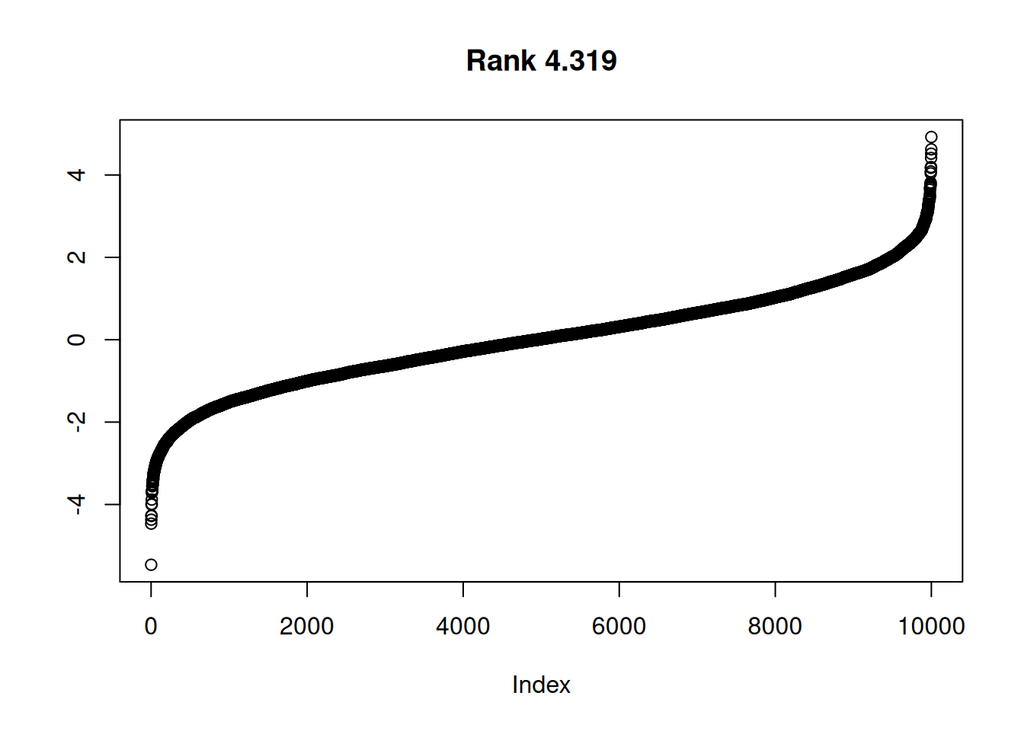

```r
sim <- 10000
sim.diff <- matrix(0, nrow= sim, ncol = 12)
sim.pVal <- matrix(0, nrow= sim, ncol = 12)
mean.diff <- function(x) mean(x[1:n1])-mean(x[(n1+1):(n1+n2)])
diff.sim <- numeric()
ge.cnt <- 0

for (j in 1:12){
for (i in 1:sim){
  data <- rnorm(n1+n2, X, sd)
  diff.sim[i] <- mean.diff(data)

  sim.diff[i, j] <- diff.sim[i]

  sim.pVal[i,j] <- t.test(data[1:n1],data[(n1+1):(n1+n2)])$p.value

  if (diff.sim[i] >= mean.difference){
    ge.cnt <- ge.cnt + 1
  }
}
}

sim.p.rk <- matrix(0, nrow = sim, ncol = 12)

for (j in 1:12){
sim.p.rk[,j] <- rank(-abs(sim.diff[,j]))/sim
}

plot(sort(diff.sim),main=paste("Rank",
  ge.cnt/sim),ylab="")
```

```r
corr <- cor.test(sim.p.rk, sim.pVal)$p.value
```

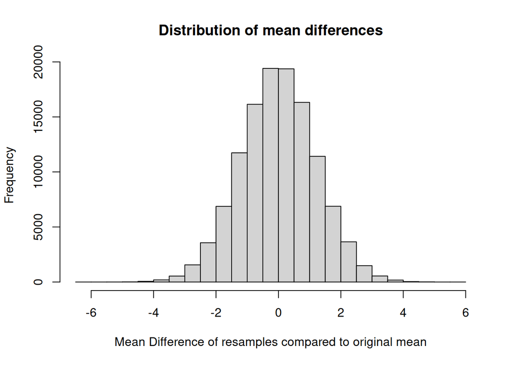

```r
hist(sim.diff, xlab="Mean Difference of resamples compared to original mean", main="Distribution of mean differences")
```

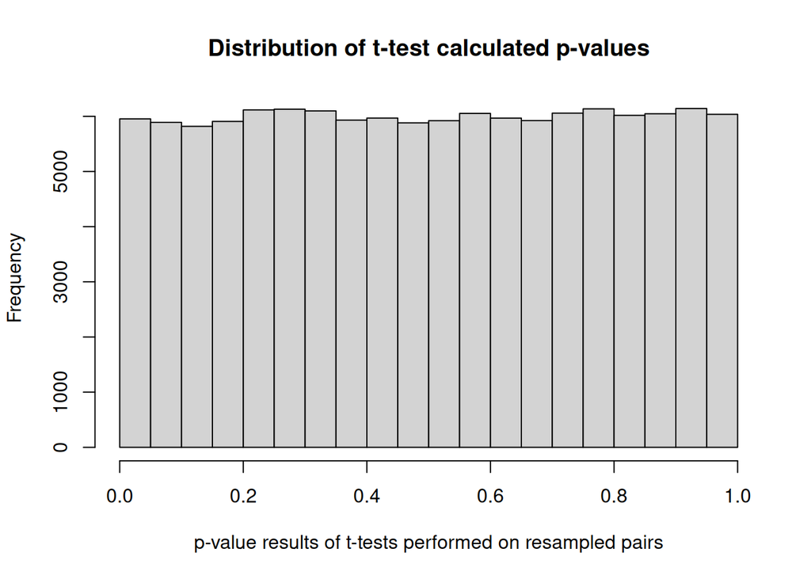

```r
hist(sim.pVal, xlab = "p-value results of t-tests performed on resampled pairs", main="Distribution of t-test calculated p-values")
```

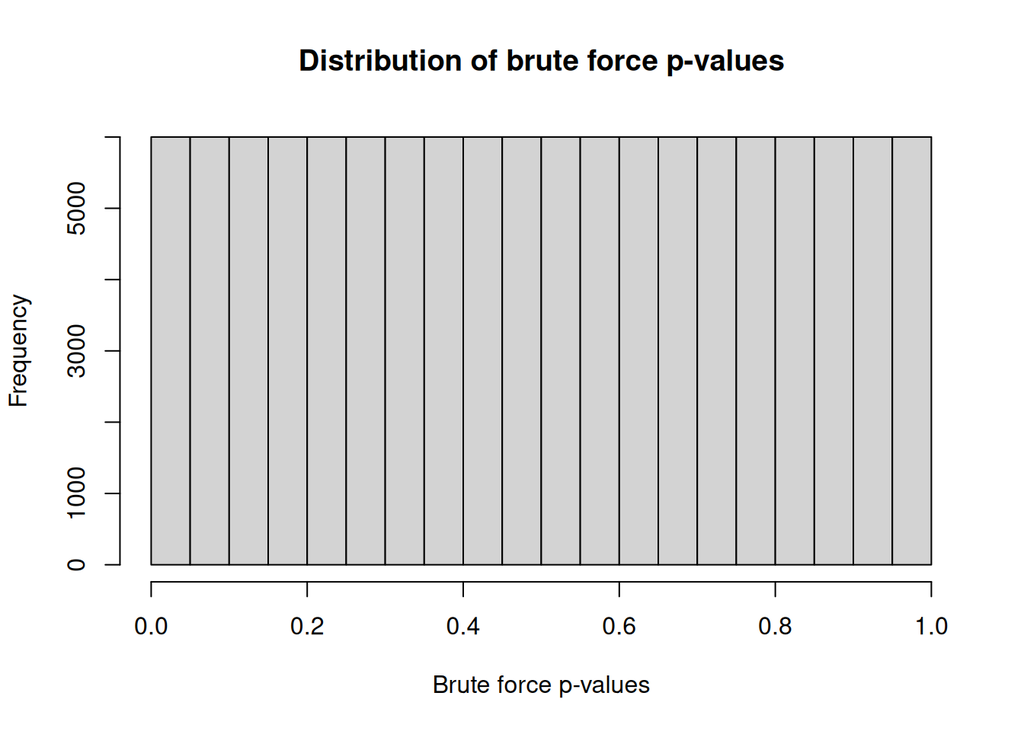

```r
hist(sim.p.rk, xlab = "Brute force p-values", main="Distribution of brute force p-values")
```

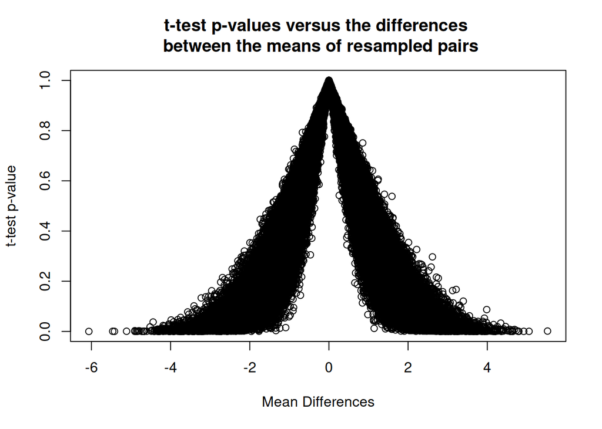

```r
plot(sim.diff, sim.pVal, xlab = "Mean Differences", ylab = "t-test p-value", main = "t-test p-values versus the differences \n between the means of resampled pairs")
```

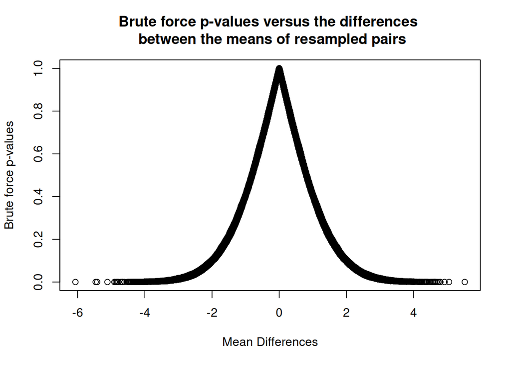

```r
plot(sim.diff, sim.p.rk, xlab = "Mean Differences", ylab="Brute force p-values", main="Brute force p-values versus the differences \n between the means of resampled pairs")
```

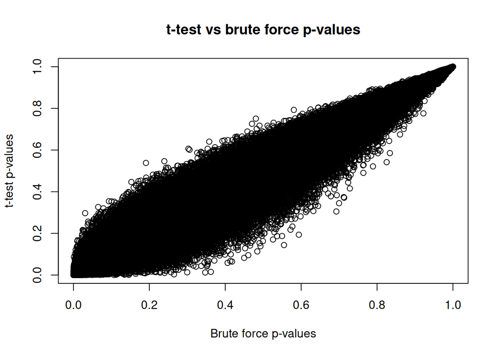

```r
plot(sim.p.rk,sim.pVal, xlab = "Brute force p-values", ylab="t-test p-values", main="t-test vs brute force p-values")
```

Now repeated with larger sample sizes

```r
set.seed(1234)
X <- 30
sd <- 2.5

n1 <- 28
n2 <- 44

data.1 <- rnorm(n1, X, sd)
data.2 <- rnorm(n2, X, sd)

mean.difference <- mean(data.1)-mean(data.2)

pVal <- t.test(data.1, data.2)$p.value
```

The normal distribution with a mean of 30 and standard deviation of 2.5, when sampled twice with two different sample sizes (28 & 44) had a difference in means of -0.0396288. A t-test was performed on this data, with the null hypothesis being “the samples came from the same distribution”. This t-test had a p-value of 0.947128, thus indicating the null hypothesis cannot be rejected.

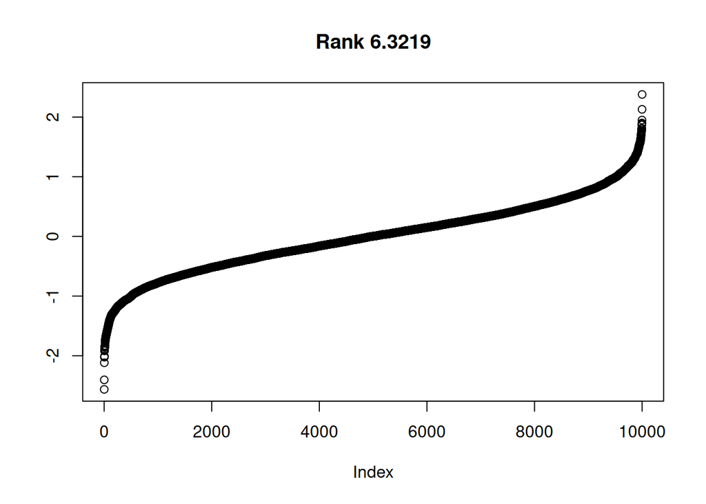

```r
sim <- 10000
sim.diff <- matrix(0, nrow= sim, ncol = 12)
sim.pVal <- matrix(0, nrow= sim, ncol = 12)
mean.diff <- function(x) mean(x[1:n1])-mean(x[(n1+1):(n1+n2)])
diff.sim <- numeric()
ge.cnt <- 0

for (j in 1:12){
for (i in 1:sim){
  data <- rnorm(n1+n2, X, sd)
  diff.sim[i] <- mean.diff(data)

  sim.diff[i, j] <- diff.sim[i]

  sim.pVal[i,j] <- t.test(data[1:n1],data[(n1+1):(n1+n2)])$p.value

  if (diff.sim[i] >= mean.difference){
    ge.cnt <- ge.cnt + 1
  }
}
}

sim.p.rk <- matrix(0, nrow = sim, ncol = 12)

for (j in 1:12){
sim.p.rk[,j] <- rank(-abs(sim.diff[,j]))/sim
}

plot(sort(diff.sim),main=paste("Rank",
  ge.cnt/sim),ylab="")
```

```r
corr <- cor.test(sim.p.rk, sim.pVal)$p.value
```

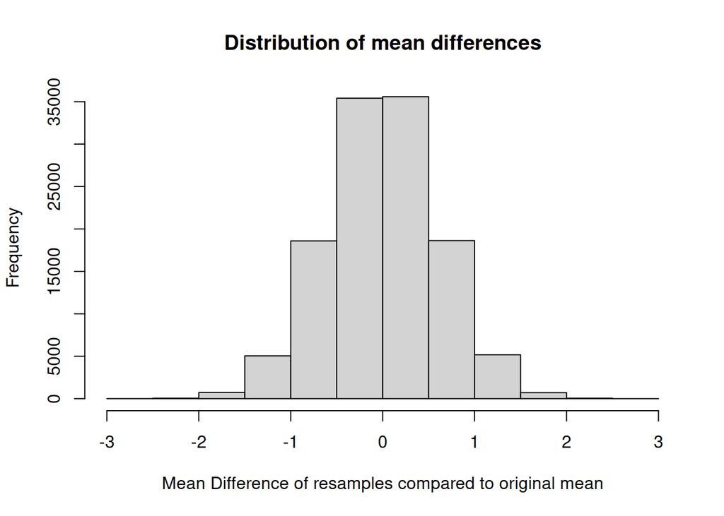

```r
hist(sim.diff, xlab="Mean Difference of resamples compared to original mean", main="Distribution of mean differences")
```

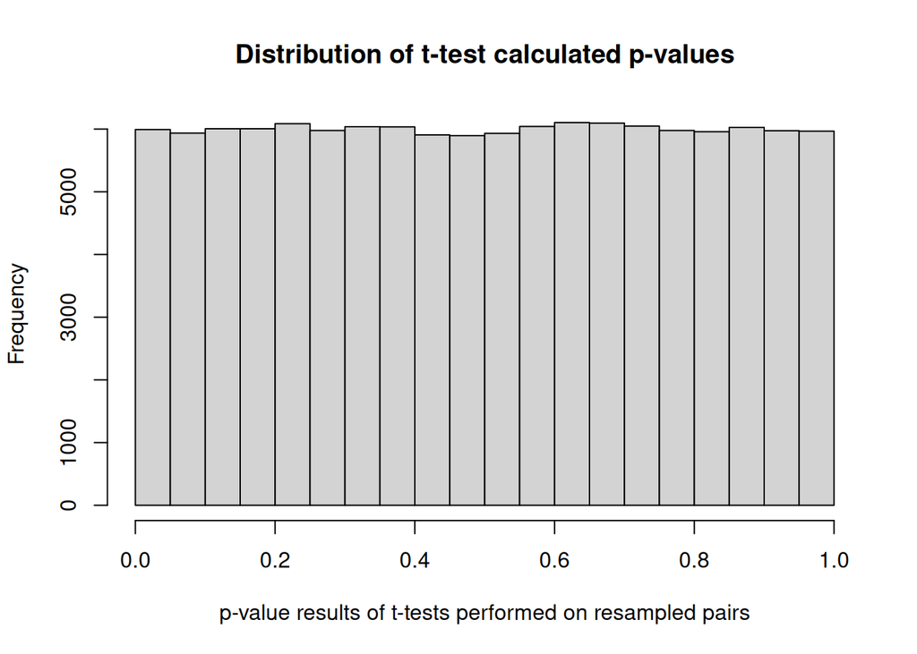

```r
hist(sim.pVal, xlab = "p-value results of t-tests performed on resampled pairs", main="Distribution of t-test calculated p-values")
```

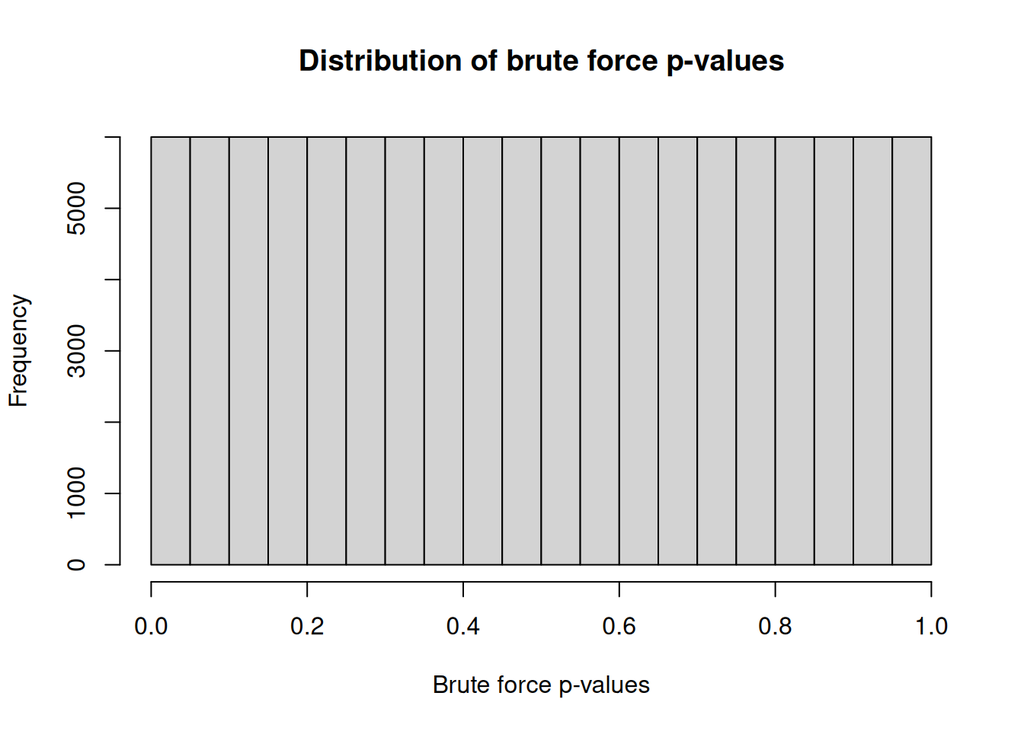

```r
hist(sim.p.rk, xlab = "Brute force p-values", main="Distribution of brute force p-values")
```

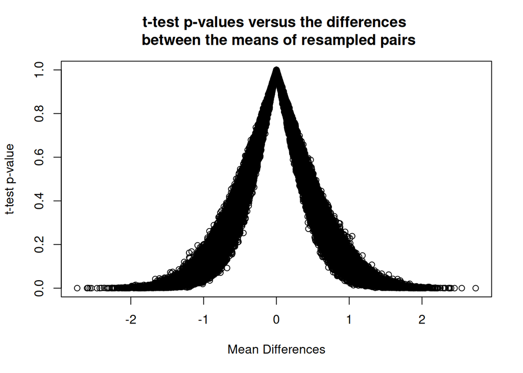

```r
plot(sim.diff, sim.pVal, xlab = "Mean Differences", ylab = "t-test p-value", main = "t-test p-values versus the differences \n between the means of resampled pairs")
```

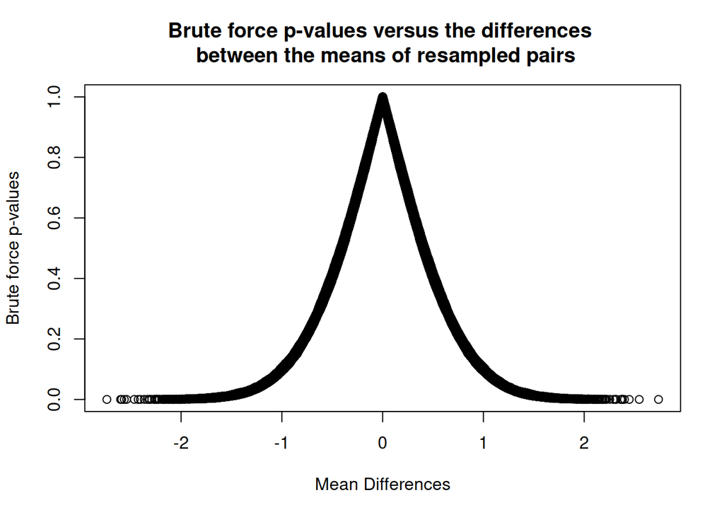

```r
plot(sim.diff, sim.p.rk, xlab = "Mean Differences", ylab="Brute force p-values", main="Brute force p-values versus the differences \n between the means of resampled pairs")
```

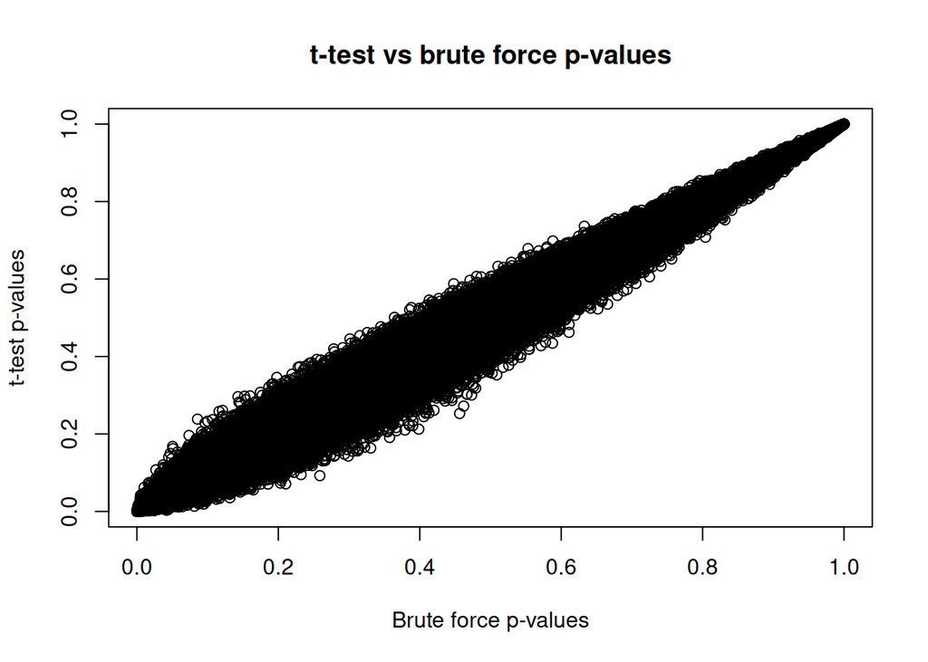

```r
plot(sim.p.rk,sim.pVal, xlab = "Brute force p-values", ylab="t-test p-values", main="t-test vs brute force p-values")
```

As the sample sizes increase, we can observe tighter distribution around the t-test p-values to mean differences. Additionally, the scatter plot showing relationship between t-test p-values and brute force p-values shows a tighter clustering of points (correlation p-value: 0).

## Question 3

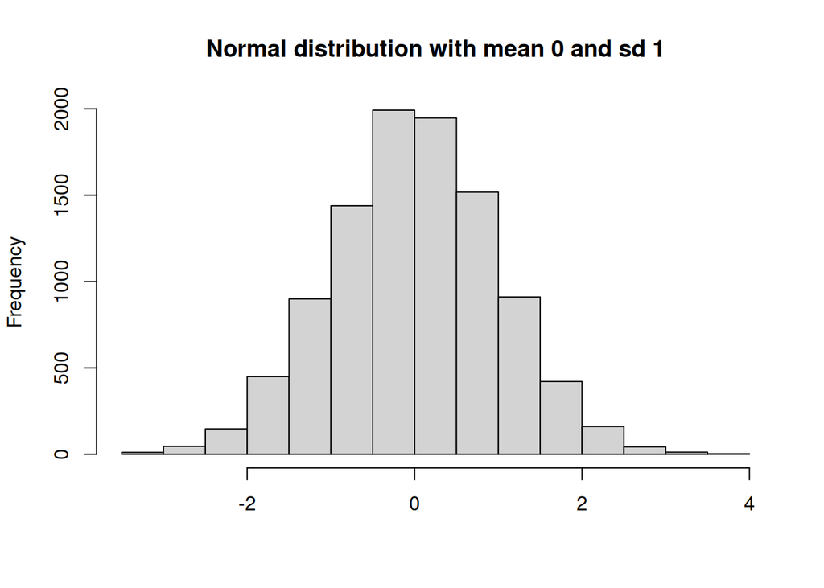

```r
set.seed(1234)
distSize <- 10000
dist.1 <- rnorm(distSize, mean=0, sd =1)
dist.2 <- c(rnorm(distSize/2, mean = -10, sd =1),rnorm(distSize/2, mean = 10, sd =1))

hist(dist.1, xlab = "", main= "Normal distribution with mean 0 and sd 1")
```

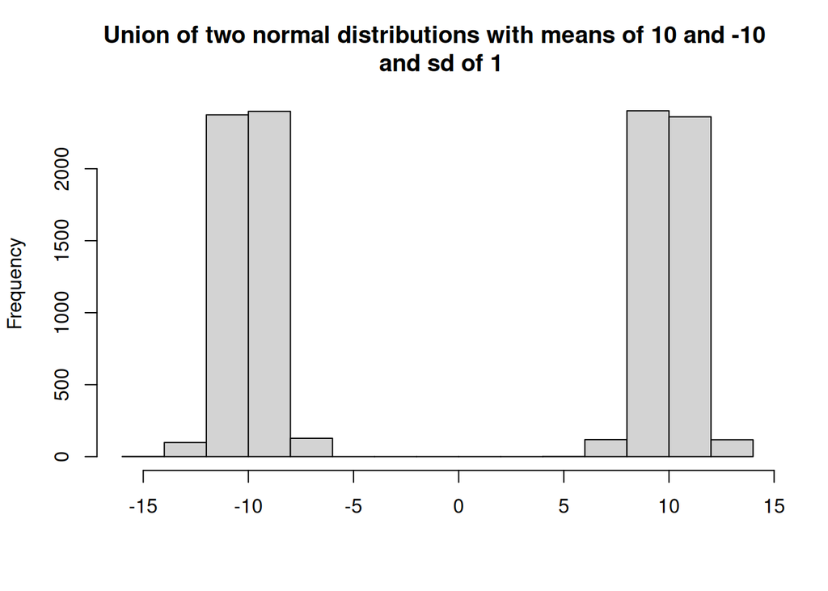

```r
hist(dist.2, xlab='', main="Union of two normal distributions with means of 10 and -10 \n and sd of 1")
```

```r
mean.1 <- mean(dist.1)
mean.2 <- mean(dist.2)

sampleSize <- 15

sample.1 <- sample(dist.1, sampleSize)
sample.2 <- sample(dist.2, sampleSize)

pVal <- t.test(sample.1, sample.2)$p.value
```

As we can see above, the two distributions have means centered around zero (0.0061159 and -0.007747), additionally if we take a sample of 15 values from each distribution and perform a t-test we observe non-significat p-values (0.7516339).

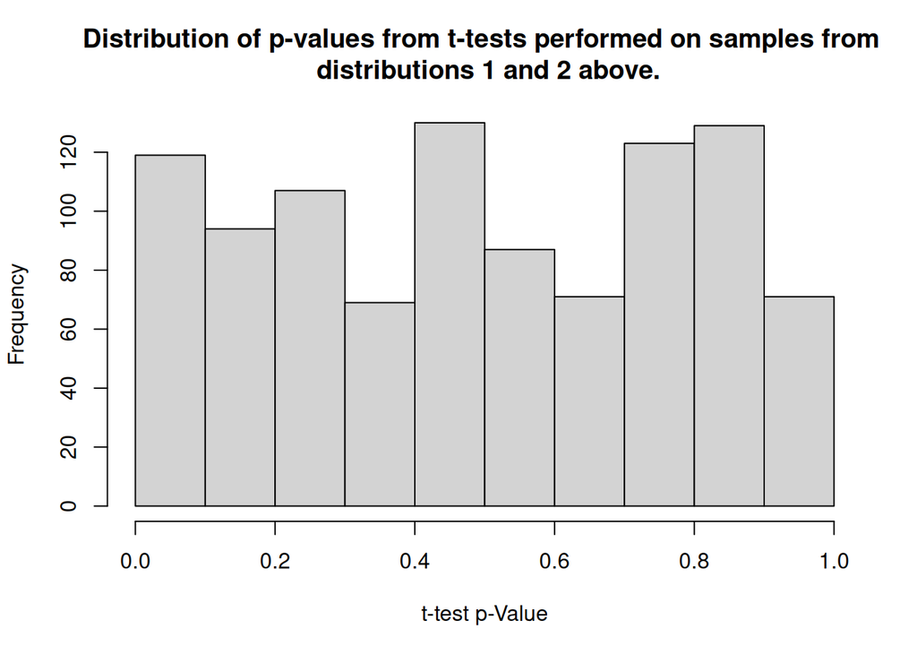

```r
sim <- 1000

sim.pVal <- numeric()

for (i in 1:sim){
  x.1 <- sample(dist.1, sampleSize)
  x.2 <- sample(dist.2, sampleSize)
  sim.pVal[i] <- t.test(x.1, x.2)$p.value
}

hist(sim.pVal, xlab = "t-test p-Value", main="Distribution of p-values from t-tests performed on samples from \n distributions 1 and 2 above.")
```

The distribution of p-values in figure above display show near uniform distribution of p-values between 0 and 1. This distribution implies that we cannot reject our null hypothesis, as the repeat t-test p-values often lies above significant (p = 0.05), thus we cannot determine that the values come from two different distributions.

## Question 4

### Question 4A

```r
# Not sure if "by hand" meant not using the choose(n,k) function from base R, here I write by own.
nChooseK <- function(n, k){
  val <- factorial(n)/(factorial(k)*factorial(n-k))
  return(val)
}

biNom.prob <- function(n, k, p){
  val <- (p^k)*(1-p)^(n-k)
}
sens <- 0.8
n <- 15
k <- 10

combinatorics <- nChooseK(n,k)

prob <- biNom.prob(n, k, sens)

probability <- combinatorics*prob
```

The probability of 10 patients out of 15 patients testing positive with an assay sensitivity of 0.8 is 0.1031823. The example above calculated this using the binomial probability equation involving n choose k.

### Question 4B

```r
dbinom.probability <- dbinom(k, n, sens)
```

Using the dbinom() function in R (prob: 0.1031823) we can see that we get the same value as the “by hand” calculated probability (0.1031823).

### Question 4C

```r
sum.prob <- 0
for (i in 1:(n-k)){
  sum.prob <- sum.prob + dbinom((k+i), n, sens)
}


q <- 10

pbinom.p <- pbinom(q, n, sens, lower.tail = FALSE)
```

### Question 4D

```r
sim <- 10000


sim.dist <- rbinom(sim, n, sens)
tenPositive <- 0
for (i in 1:length(sim.dist)){
  if(sim.dist[i] >= 10){
    tenPositive <- tenPositive + 1
  }
}
prop.tenOrMore <- tenPositive/sim
```

### Question 4E

```r
p<-0.05
val <- qbinom(p, 15, sens, lower.tail = FALSE)
```

The smallest number of tests to get a probability less than or equal to 0.05 that will result in less than 15 positive tests. This value is 14.

## Question 5

```r
library(DBI)
library(duckdb)
library(repoquet)
config_path <- "~/Documents/Brandeis/rbif111/homework/database/repoquet_public_example/repository_config.R"
cfg <- load_repository_config(config_path)
temp_dir <- file.path(cfg$FormattedDBPath, "duckdb_temp")
dir.create(temp_dir, recursive = TRUE, showWarnings = FALSE)
con <- open_duckdb( FormattedDBPath = cfg$FormattedDBPath, DBName = cfg$DBName, TempDirPath = temp_dir, GB = cfg$DuckDB_GB, ReadOnly = TRUE)
```

[output not shown]

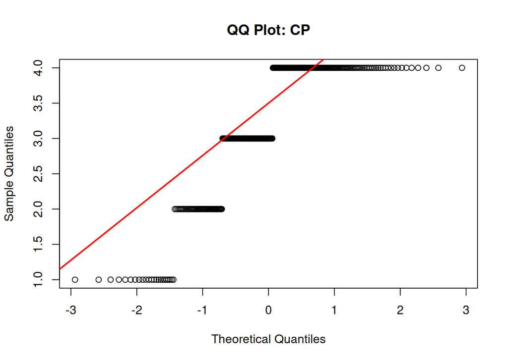

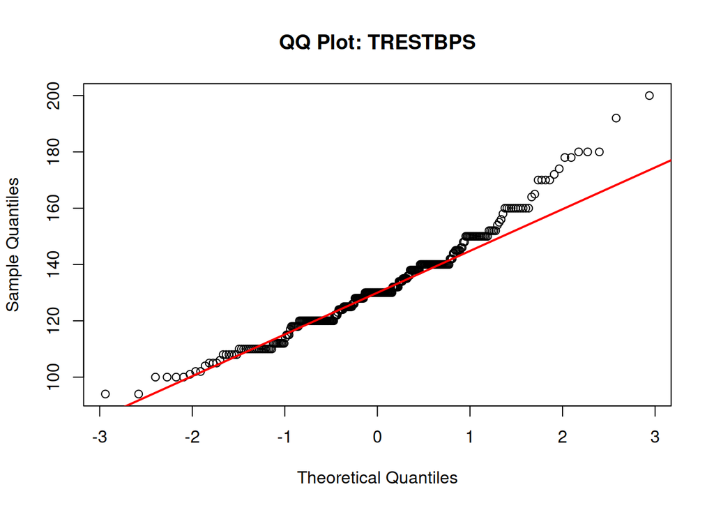

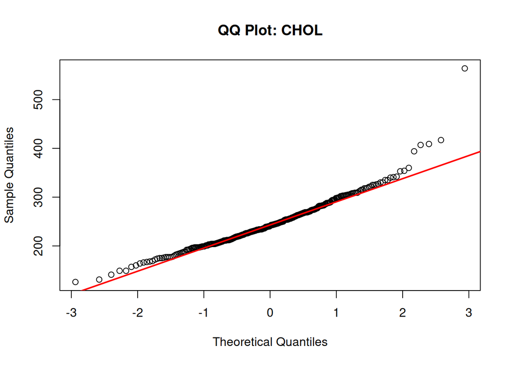

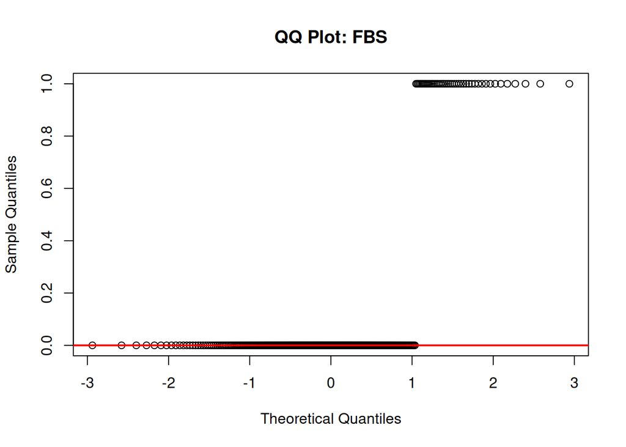

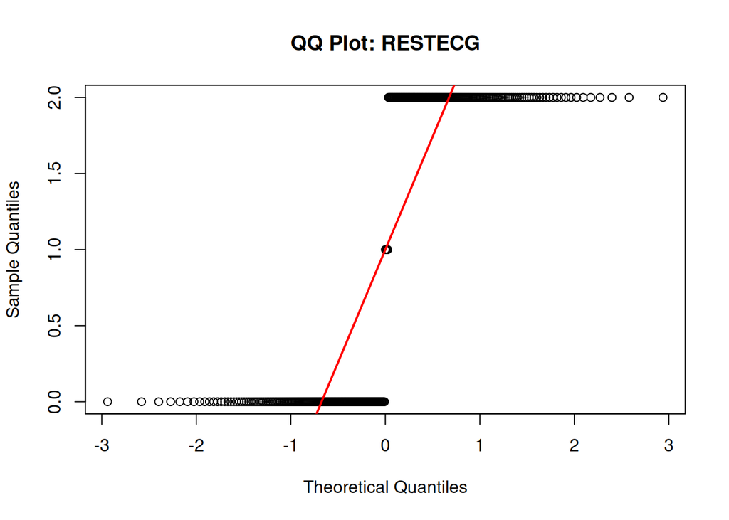

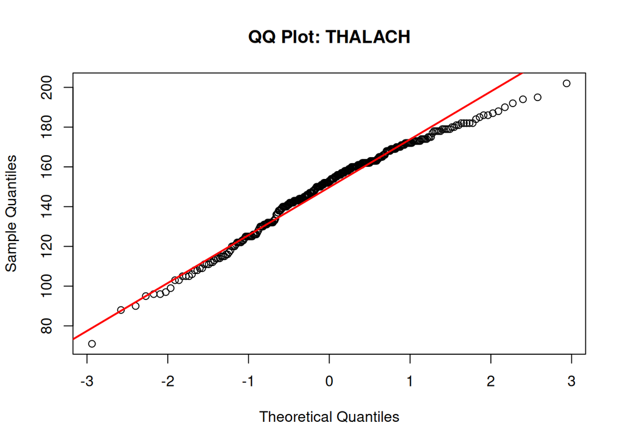

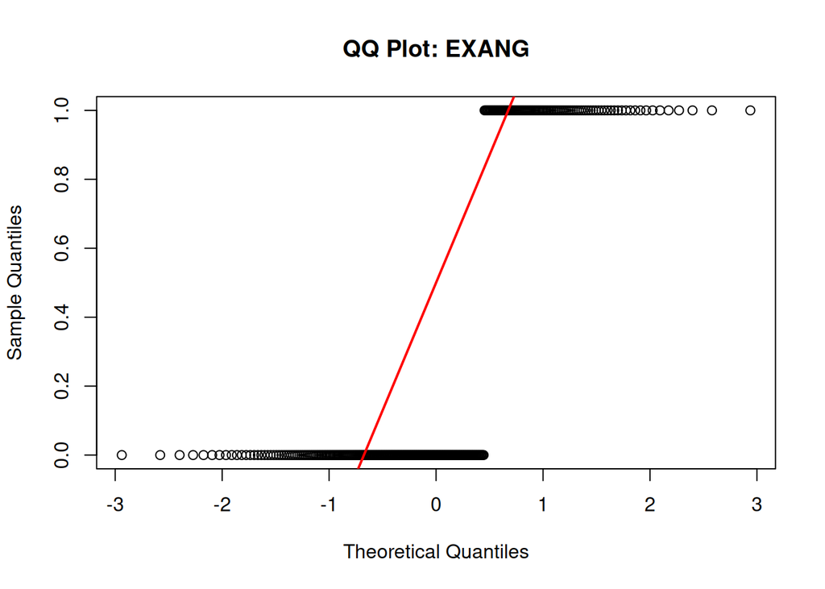

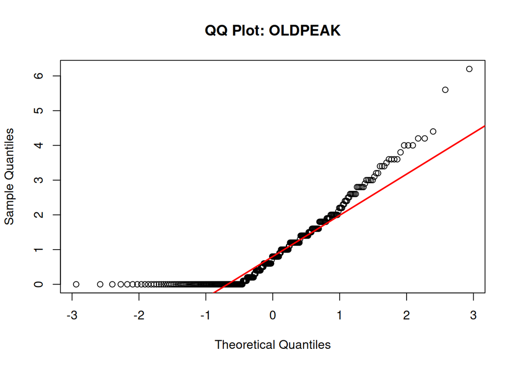

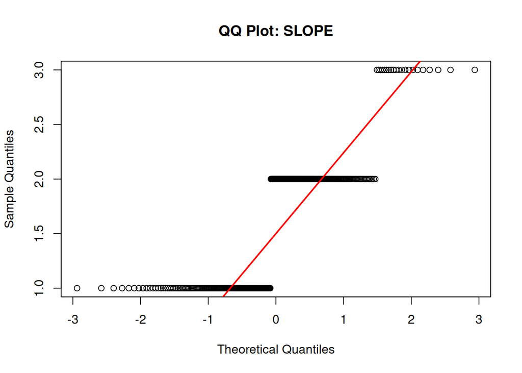

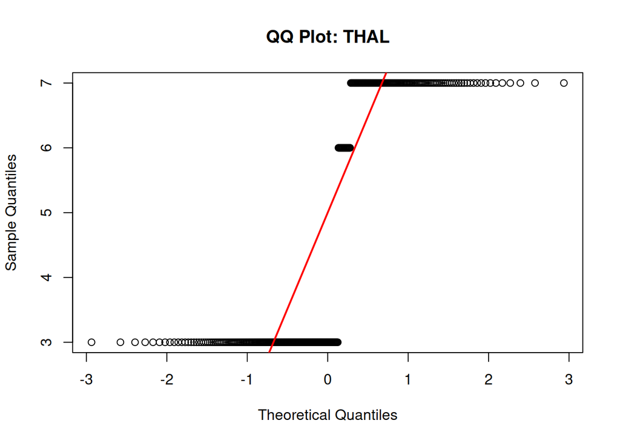

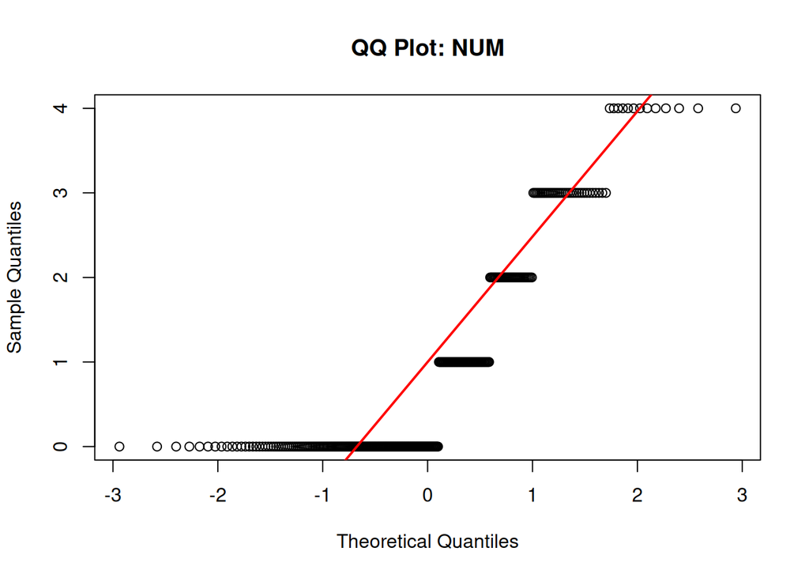

```r
uci_tables <- DBI::dbListTables(con)
data <- uci_tables[529]
data <- DBI::dbGetQuery(con,paste("SELECT * FROM", data))

# From documentation I found that the disease diagnosis is found in the "NUM" column (1)

y.HD <- data[data$NUM > 0,]
n.HD <- data[data$NUM == 0,]

intCols <- c(3:11,13:14)
shapiroVals <- numeric(length(intCols))
cols <- numeric()
for (i in 1:length(intCols)){
  index <- intCols[i]
  val <- data[,index]
  shapiroVals[i] <- shapiro.test(val)$p.value
  cols[i] <- colnames(data[index])
  qqnorm(val, main=paste("QQ Plot:", colnames(data[index])))
  qqline(val, col = "red", lwd=2)
}
```

```r
DT <- data.frame(
  "Column Name" = cols,
  "Shapiro-Wilks Test p-value" = shapiroVals
)
DT
```

```
##    Column.Name Shapiro.Wilks.Test.p.value
## 1           CP               1.990307e-19
## 2     TRESTBPS               1.802064e-06
## 3         CHOL               5.911521e-09
## 4          FBS               5.430898e-30
## 5      RESTECG               1.201869e-24
## 6      THALACH               6.996471e-05
## 7        EXANG               3.846846e-26
## 8      OLDPEAK               8.183378e-17
## 9        SLOPE               2.574779e-21
## 10        THAL               3.383516e-24
## 11         NUM               5.594371e-21
```

From the p-values calculated from the Shapiro-Wilks test observed in the data table above, we can reject the null hypothesis for each column tested. The null hypothesis in this case is “the data is normally distributed”, thus we can determine that of all the numerical columns in the heart disease data set none are normally distributed.

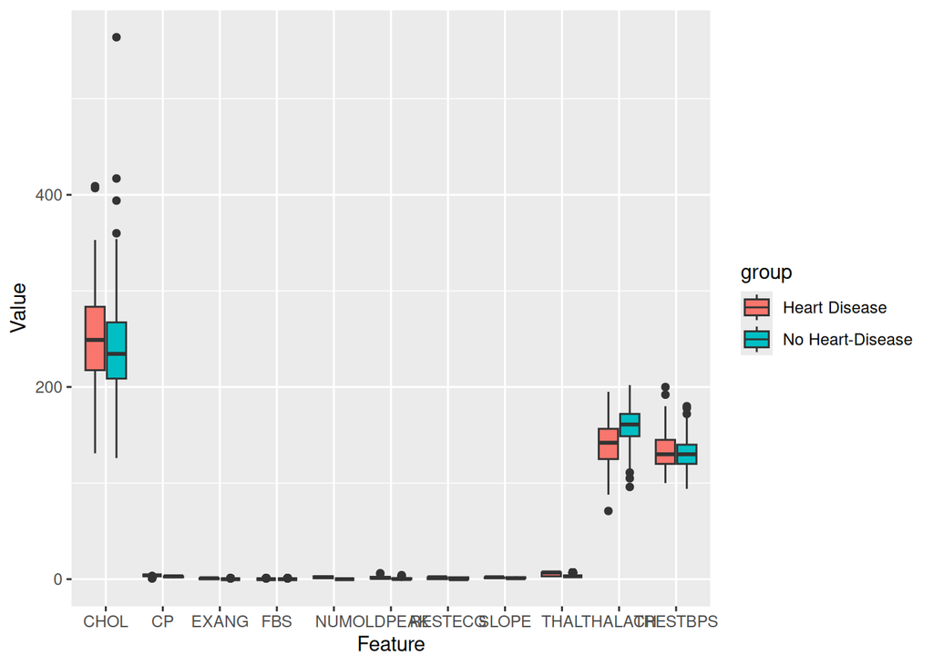

```r
library(ggplot2)
library(tidyr)
library(dplyr)
data$group <- ifelse(data$NUM == 0, "No Heart-Disease", "Heart Disease")

pivotDY <- data %>%
  pivot_longer(
    cols = all_of(cols),
    names_to = "Feature",
    values_to = "Value"
  )

ggplot(pivotDY, aes(x = Feature, y = Value, fill = group)) + geom_boxplot()
```

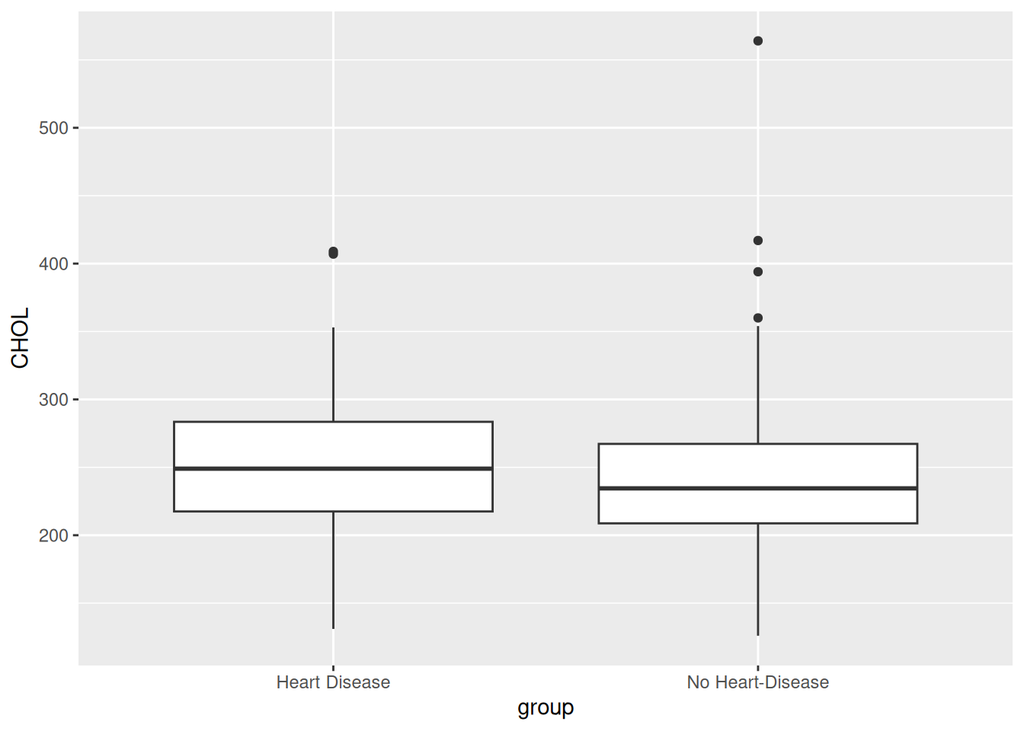

```r
ggplot(data, aes(x=group, y=CHOL)) + geom_boxplot()
```

I did have an issue with this question, where I was unsure how to plot the boxplot properly with how the original data table was setup. I did resort to AI to help me setup the data table properly, from the response I was able to learn how to use the pivot function in R which formatted the table how I needed (2). In order to test the AI response, I decided to test if making a simple box plot that has grouping on the x-axis , CHOL value on the y-axis appeared similar to the two box plots made from pivot table. The result of this test showed that yes the pivot table method to create complex boxplot worked.

Let’s perform statistical test based on the p-value of the shapiro-wilks test.

```r
testVal <- numeric(length(intCols))
statTest <- character(length(intCols))
for (i in 1:length(intCols)){
  index <- intCols[i]
  col <- colnames(data[index])
  pVal <- shapiroVals[i]
  if (pVal <= 0.05){
    testVal[i] <- wilcox.test(y.HD[[col]], n.HD[[col]])$p.value
    statTest[i] <- "Mann-Whitney U Test"
  } else{
    testVal[i] <- t.test(y.HD[[col]], n.HD[[col]])$p.value
    statTest[i] <- "t-test"
  }

}

DT <- data.frame(
  "Column Name" = cols,
  "Statistical Test Performed" = statTest,
  "Statistical Test p-value" = testVal
)
DT
```

```
##    Column.Name Statistical.Test.Performed Statistical.Test.p.value
## 1           CP        Mann-Whitney U Test             2.220446e-16
## 2     TRESTBPS        Mann-Whitney U Test             2.597211e-02
## 3         CHOL        Mann-Whitney U Test             3.535920e-02
## 4          FBS        Mann-Whitney U Test             6.614098e-01
## 5      RESTECG        Mann-Whitney U Test             3.271821e-03
## 6      THALACH        Mann-Whitney U Test             1.861015e-13
## 7        EXANG        Mann-Whitney U Test             6.150636e-14
## 8      OLDPEAK        Mann-Whitney U Test             6.812328e-13
## 9        SLOPE        Mann-Whitney U Test             2.415304e-10
## 10        THAL        Mann-Whitney U Test             0.000000e+00
## 11         NUM        Mann-Whitney U Test             0.000000e+00
```

## Question 6

```r
# Let's find the numerical columns with greatest variance and overlap
y.col.var <- numeric(length(intCols))
n.col.var <- numeric(length(intCols))
y.col.mean <- numeric(length(intCols))
n.col.mean <- numeric(length(intCols))
for (i in 1:length(intCols)){
  index <- intCols[i]
  y.col.var[i] <- var(y.HD[[index]], na.rm=TRUE)
  n.col.var[i] <- var(n.HD[[index]], na.rm=TRUE)
  y.col.mean[i] <- mean(y.HD[[index]], na.rm=TRUE)
  n.col.mean[i] <- mean(n.HD[[index]], na.rm=TRUE)
}

DT <- data.frame(
  "Column Name" = cols,
  "Yes HD mean" = y.col.mean,
  "Yes HD var" = y.col.var,
  "No HD mean" = n.col.mean,
  "No HD var" = n.col.var
)
DT
```

```
##    Column.Name Yes.HD.mean   Yes.HD.var  No.HD.mean    No.HD.var
## 1           CP   3.5899281    0.6784485   2.7926829    0.8401915
## 2     TRESTBPS 134.5683453  352.2760922 129.2500000  262.5935583
## 3         CHOL 251.4748201 2448.9468251 242.6402439 2857.6059779
## 4          FBS   0.1582734    0.1341883   0.1402439    0.1213153
## 5      RESTECG   1.1726619    0.9554791   0.8353659    0.9727293
## 6      THALACH 139.2589928  510.4541758 158.3780488  368.6046686
## 7        EXANG   0.5467626    0.2496090   0.1402439    0.1213153
## 8      OLDPEAK   1.5741007    1.6967157   0.5865854    0.6111073
## 9        SLOPE   1.8273381    0.3177979   1.4085366    0.3535463
## 10        THAL   5.8405797    3.0546916   3.7975460    2.4587594
## 11         NUM   2.0431655    1.0271087   0.0000000    0.0000000
```

From this data table, I determined the “CHOL” column to have the greatest variance and overlap, due to the mean proximity between groups and large variance value observed.